# Single Cell RNA-Seq Analysis and Visualization Workshop

### Saving Seurat objects

Seurat objects can be saved at any point (in .RDS format)

Here we save the new Seurat objects for easy access later, so we don’t need to re-run the `CreateSeuratObject()` function each time we start a new analysis.

```r
# save the Seurat object in .RDS format for easy access later
# this way we will not need to re-run the CreateSeuratObject command before every analysis
# give this file an informative name so that we know what its contents are
saveRDS(pfc2, "pfc2-unprocessed-200g-seurat-object.RDS")
saveRDS(pfc3, "pfc3-unprocessed-200g-seurat-object.RDS")
saveRDS(pfc5, "pfc5-unprocessed-200g-seurat-object.RDS")
saveRDS(pfc7, "pfc7-unprocessed-200g-seurat-object.RDS")

# to reload this object from a saved file, use the following command
# since we already have the data loaded for now, we do not need to use this command
pfc2 <- readRDS("pfc2-unprocessed-200g-seurat-object.RDS")
pfc3 <- readRDS("pfc3-unprocessed-200g-seurat-object.RDS")
pfc5 <- readRDS("pfc5-unprocessed-200g-seurat-object.RDS")
pfc7 <- readRDS("pfc7-unprocessed-200g-seurat-object.RDS")
```

# Metadata & Quality Control

### Inspecting object metadata

```r
# inspect the metadata for one of our objects using the 'head' function
head(pfc2@meta.data)
```

|  | orig.ident | nCount_RNA | nFeature_RNA |
| --- | --- | --- | --- |
| AAACCTGCAGAGCCAA-1 | pfc-demo | 2504 | 1110 |
| AAACCTGGTTAAGATG-1 | pfc-demo | 2555 | 836 |
| AAACGGGAGCTACCGC-1 | pfc-demo | 2779 | 1186 |
| AAACGGGAGTTACCCA-1 | pfc-demo | 17859 | 4716 |
| AAACGGGTCCCGACTT-1 | pfc-demo | 2695 | 856 |
| AAAGATGCAGCTGCAC-1 | pfc-demo | 9735 | 3119 |

### Adding custom metadata

If desired, you can add custom metadata to a Seurat object using the following command structure. Simply replace `sample_number` with any desired metadata slot name.

This is particularly useful for comparing/combining multiple samples or treatments.

In this case, we will add a custom metadata slot called `sample_number`, which contains the original sample number for each pfc object.

```r
pfc2@meta.data$sample_number <- "2"
pfc3@meta.data$sample_number <- "3"
pfc5@meta.data$sample_number <- "5"
pfc7@meta.data$sample_number <- "7"
```

### Merging Seurat objects

Now that each sample has a unique metadata identifier, we can merge them into a single `Seurat` object for easier downstream processing.

```r
# merge multiple Seurat objects
pfc <- merge(x = pfc2, y = list(pfc3, pfc5, pfc7))
# remove individual objects to save processing space
rm(pfc2, pfc3, pfc5, pfc7)

# inpect our new combined object
pfc
```

```
## An object of class Seurat
## 16901 features across 6401 samples within 1 assay
## Active assay: RNA (16901 features, 0 variable features)
```

### Mitochondrial gene ratio

To select high quality cells for downstream analysis, it is common to assess the ratio of reads that map to the mitochondrial genome in each cell. Low quality and/or dying cells often exhibit a high proportion of mitochondrial transcripts.

Note: If your cell type of interest is known to have a high proportion of mitochondrial transcripts, consider relaxing this threshold.

To add a metadata slot for mitochondrial gene ratio, called `percent.mt`, we use the `PercentageFeatureSet` function included in Seurat.

```r
# an important metadata slot to add in every experiment is the ratio of mitochondrial genes
# detected in each cell - this can be used as a proxy for cell quality in most preparations

pfc[["percent.mt"]] <- PercentageFeatureSet(object = pfc, pattern = "^mt-")
```

```r
# inspect the metadata for our object using the 'head' function to see our new metadata column(s)
head(pfc@meta.data)
```

|  | orig.ident | nCount_RNA | nFeature_RNA | sample_number | percent.mt |
| --- | --- | --- | --- | --- | --- |
| AAACCTGCAGAGCCAA-1_1 | pfc-demo | 2504 | 1110 | 2 | 2.476038 |
| AAACCTGGTTAAGATG-1_1 | pfc-demo | 2555 | 836 | 2 | 2.896282 |
| AAACGGGAGCTACCGC-1_1 | pfc-demo | 2779 | 1186 | 2 | 18.639799 |
| AAACGGGAGTTACCCA-1_1 | pfc-demo | 17859 | 4716 | 2 | 3.130075 |
| AAACGGGTCCCGACTT-1_1 | pfc-demo | 2695 | 856 | 2 | 35.287570 |
| AAAGATGCAGCTGCAC-1_1 | pfc-demo | 9735 | 3119 | 2 | 3.605547 |

### Quality Control Filtering

I like to begin filtering data by removing any cells with a high proportion of mitochondrial transcripts. To select a threshold for trimming low quality cells, we can visualize the `percent.mt` metric in a Violin Plot.

The `y.max` parameter sets a y-axis cutoff so we can zoom into the threshold range of values (typically I set percent.mt thresholds somewhere between 5-10%)

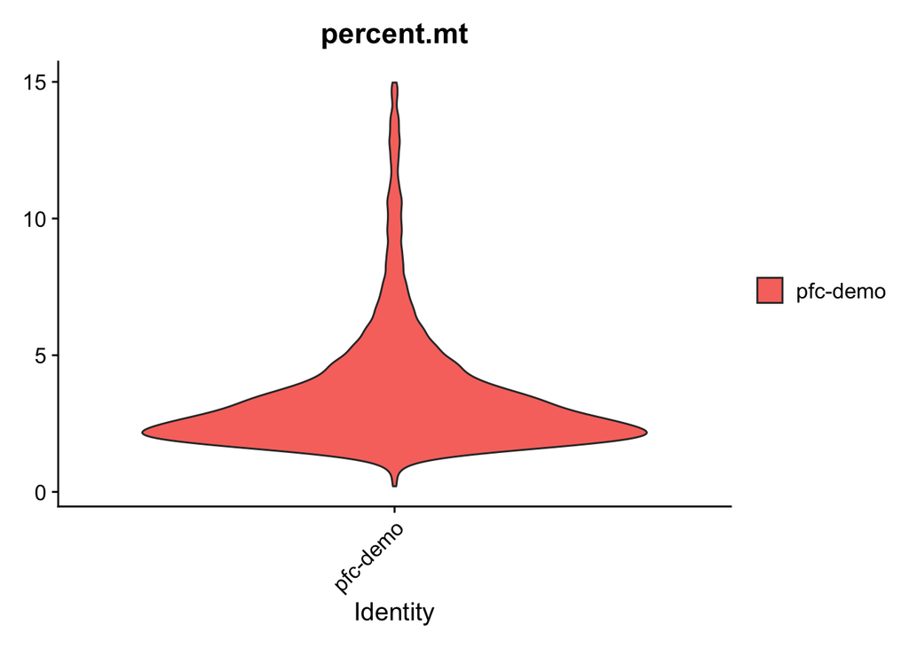

```r
# percent.mt cutoffs typically range from 5-10% depending on the sample

VlnPlot(pfc, features = c("percent.mt"), pt.size=0, y.max=15)
```

In this data, most cells have <5% percent.mt, so we will remove all cells above this threshold.

```r
pfc <- subset(pfc, subset = percent.mt < 5)
```

```r
# inspect the object again to see how many cells were removed
pfc
```

```
## An object of class Seurat
## 16901 features across 5125 samples within 1 assay
## Active assay: RNA (16901 features, 0 variable features)
```

Two additional metrics that can be used to filter low quality cells are:

`nFeature_RNA` = the number of genes detected per cell

`nCount_RNA` = the number of UMIs detected per cell

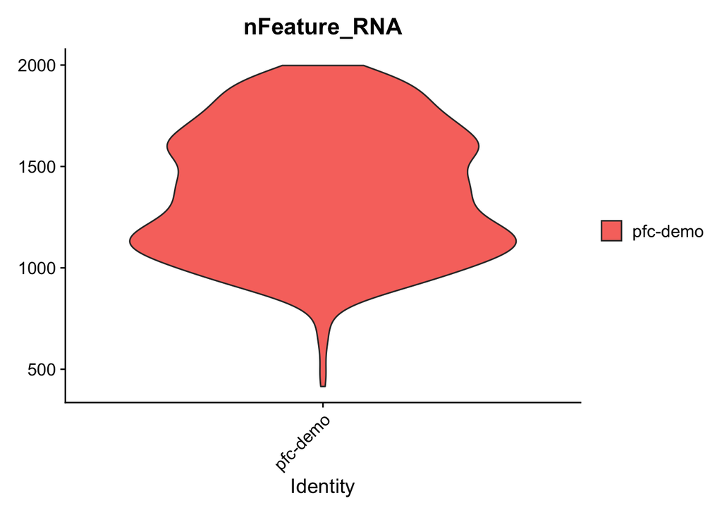

```r
VlnPlot(pfc, features = c("nFeature_RNA"), pt.size=0, y.max=2000)
```

Fortunately, this data is high quality and does not contain many cells with low nFeature_RNA

For now we will include cells with >600 nFeature_RNA

```r
pfc <- subset(pfc, subset = nFeature_RNA > 600)
```

```r
# inspect the object again to see how many cells were removed
pfc
```

```
## An object of class Seurat
## 16901 features across 5118 samples within 1 assay
## Active assay: RNA (16901 features, 0 variable features)
```

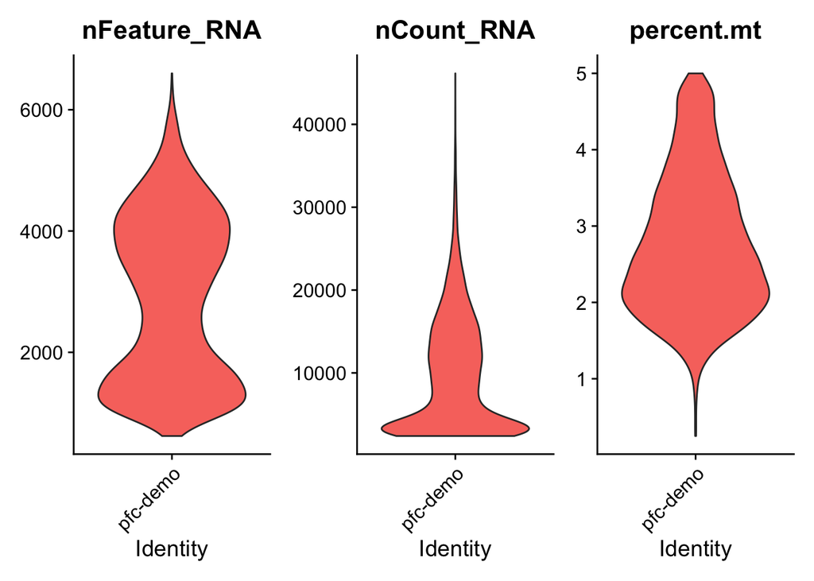

```r
# inspect our QC metrics again
VlnPlot(pfc, features = c("nFeature_RNA","nCount_RNA","percent.mt"), pt.size=0)
```

Excellent! Now we have trimmed low quality cells are ready to proceed with data analysis.

For additional information on trimming low quality cells, see: https://www.ncbi.nlm.nih.gov/pmc/articles/PMC4758103/

# SCTransform normalization & scaling

Scaling and normalization is an essential step in single cell analysis. SCTransform is an algorithm for normalization and scaling developed by the Satija lab. From their website:

“Biological heterogeneity in single-cell RNA-seq data is often confounded by technical factors including sequencing depth. The number of molecules detected in each cell can vary significantly between cells, even within the same celltype. Interpretation of scRNA-seq data requires effective pre-processing and normalization to remove this technical variability. In Hafemeister and Satija, 2019 we introduce a modeling framework for the normalization and variance stabilization of molecular count data from scRNA-seq experiment. This procedure omits the need for heuristic steps including pseudocount addition or log-transformation and improves common downstream analytical tasks such as variable gene selection, dimensional reduction, and differential expression.”

https://satijalab.org/seurat/articles/sctransform_vignette.html

We will use SCTransform to normalize our pfc object with a single command.

```r
# this may take several minutes to execute, and progress will display in the console
pfc <- SCTransform(pfc)
```

# Dimensionality reduction

```r
pfc <- RunPCA(pfc, npcs = 60)
```

```
## PC_ 1
## Positive:  Fos, Sepp1, Ly6c1, Itm2a, Ly6a, Bsg, Sparc, Id1, Flt1, Id3
##     Pltp, Ifitm3, Pglyrp1, Slc2a1, Rgs5, B2m, Btg2, Nfkbia, Myl12a, Cldn5
##     Slco1a4, Gng11, Ctla2a, Vtn, Atp1a2, Tm4sf1, H2-D1, Esam, Ly6e, Epas1
## Negative:  Meg3, Stmn1, Snap25, Calm2, Snrpn, Rtn1, Snhg11, Snca, Atp6v0c, Sncb
##     Pcp4, Aldoa, Stmn3, Vsnl1, Zwint, Bex2, Syt1, Mdh1, Atp6v1g2, Hsp90aa1
##     Mtap1b, Calm1, Dynll1, Mef2c, Arpp21, Mllt11, Stmn2, Gap43, Chn1, Ttc3
## PC_ 2
## Positive:  Cst3, Ctss, C1qa, Tyrobp, C1qb, C1qc, Fcer1g, Hexb, Ctsd, Trem2
##     Lgmn, P2ry12, Selplg, Laptm5, Csf1r, Rgs10, Aif1, Fcgr3, Fcrls, Cx3cr1
##     Gpr34, Ly86, Tmem119, Cd53, Olfml3, Siglech, Ctsz, Trf, Unc93b1, Ccl3
## Negative:  Bsg, Ly6c1, Itm2a, Ly6a, Flt1, Id1, Pltp, Id3, Pglyrp1, Rgs5
##     Slc2a1, Ifitm3, Slco1a4, Cldn5, Gng11, Ctla2a, Vtn, Esam, Tm4sf1, Epas1
##     Cald1, Meg3, Egfl7, Cxcl12, Car4, Ptprb, Ramp2, Pcp4l1, Abcg2, Ifitm2
## PC_ 3
## Positive:  Meg3, Snap25, Stmn1, Calm2, Snca, Tmsb4x, Snrpn, Rtn1, Sncb, Tmsb10
##     Snhg11, B2m, Atp6v0c, Atf3, Vsnl1, Nfkbia, Sparc, Stmn3, Zwint, Calm1
##     Mef2c, Pcp4, Zfp36, Syt1, Aldoa, Dynll1, Cyba, Bex2, Bsg, H3f3b
## Negative:  Gpr37l1, Dbi, Apoe, Ndrg2, Aldoc, Mt1, Slc1a3, Glul, Clu, Mt2
##     Prdx6, Car2, Mfge8, Tubb2b, Atp1a2, Cldn10, S100a1, Slc1a2, Pla2g7, Gstm1
##     Ppap2b, Phgdh, S100a16, Acsbg1, Gstm5, Tsc22d4, Ckb, Cst3, Mt3, S100b
## PC_ 4
## Positive:  Plp1, Cnp, Cldn11, Mbp, Cryab, Mag, Sept4, Mobp, Mog, Pllp
##     Mal, Ermn, Gatm, Trf, Ptgds, Apod, Aspa, Gsn, Enpp2, Qdpr
##     Fth1, Opalin, Cd9, Tspan2, Pdlim2, Tnfaip6, Sirt2, Tubb4a, Gpr37, Csrp1
## Negative:  Cst3, Atp1a2, Clu, Slc1a2, Aldoc, Mt3, Mfge8, Mt2, Slc1a3, Cldn10
##     Acsbg1, Prdx6, Pla2g7, Gstm1, Gja1, F3, Gjb6, Ppap2b, Sparcl1, Ndrg2
##     Mlc1, Gpr37l1, Tst, Aqp4, Mt1, Mgll, Fam107a, S1pr1, Slc9a3r1, Apoe
## PC_ 5
## Positive:  Car2, Glul, Csrp1, Fth1, Gstm1, Trf, Mal, Mobp, Ermn, Apod
##     Mog, Cst3, Sept4, Aspa, Slc1a2, Acsbg1, Mt1, Sepp1, Mt2, Mag
##     Gja1, Cldn11, Tst, Mbp, Il33, Phgdh, Pdlim2, Gjb6, Opalin, Qdpr
## Negative:  Serpine2, Scrg1, S100a1, Ptprz1, Pdgfra, Tmem100, Neu4, Qpct, S100a16, Gpr17
##     Cd9, Fabp7, Ednrb, Tmem176b, Vcan, Cacng4, S100a13, Fos, Rlbp1, Ccnd1
##     Lims2, Cdo1, Gm2a, Dbi, Olig1, Nxph1, Nnat, G0s2, S100b, Tmem176a
```

# Clustering

```r
pfc <- FindNeighbors(pfc, dims = 1:60)
pfc <- FindClusters(pfc, resolution = 0.7)
```

```
## Modularity Optimizer version 1.3.0 by Ludo Waltman and Nees Jan van Eck
##
## Number of nodes: 5118
## Number of edges: 192473
##
## Running Louvain algorithm...
## Maximum modularity in 10 random starts: 0.9184
## Number of communities: 17
## Elapsed time: 0 seconds
```

# UMAP non-linear dimensional reduction

From the Seurat authors:

“Seurat offers several non-linear dimensional reduction techniques, such as tSNE and UMAP, to visualize and explore these datasets. The goal of these algorithms is to learn the underlying manifold of the data in order to place similar cells together in low-dimensional space. Cells within the graph-based clusters determined above should co-localize on these dimension reduction plots. As input to the UMAP and tSNE, we suggest using the same PCs as input to the clustering analysis.”

```r
pfc <- RunUMAP(pfc, dims = 1:60)
```

# Plotting clustered cells

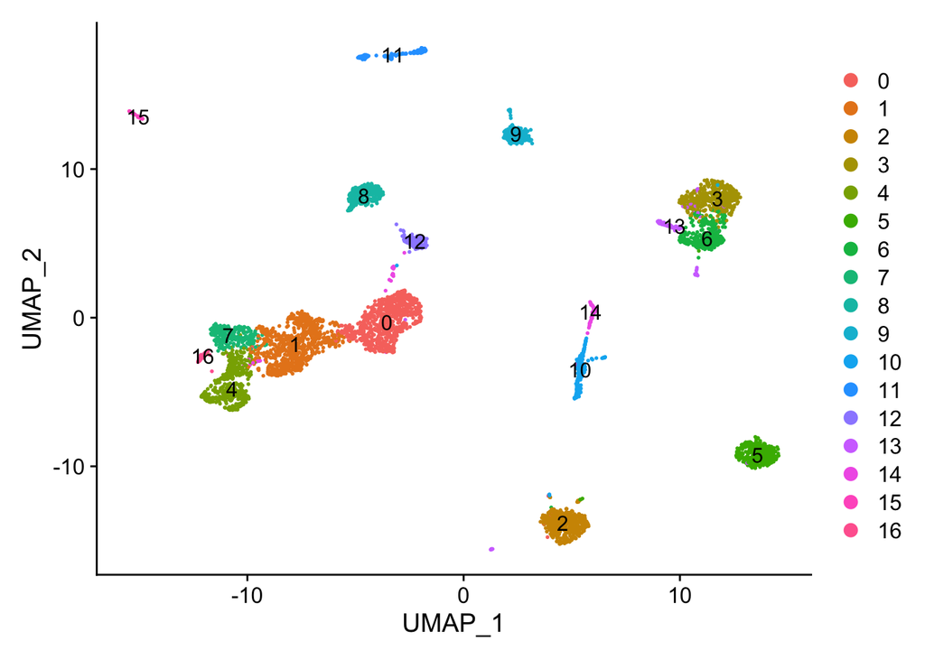

```r
DimPlot(pfc, label=T)
```

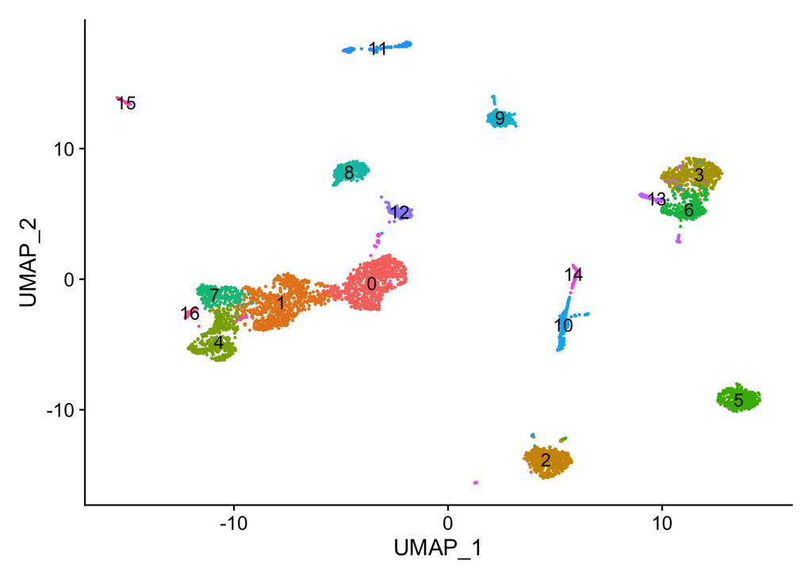

```r
DimPlot(pfc, label=T) + NoLegend()
```

We can use our custom `sample_number` metadata slot to group our cells using the `group.by` option. This will help to determine if technical variables affected our clustering.

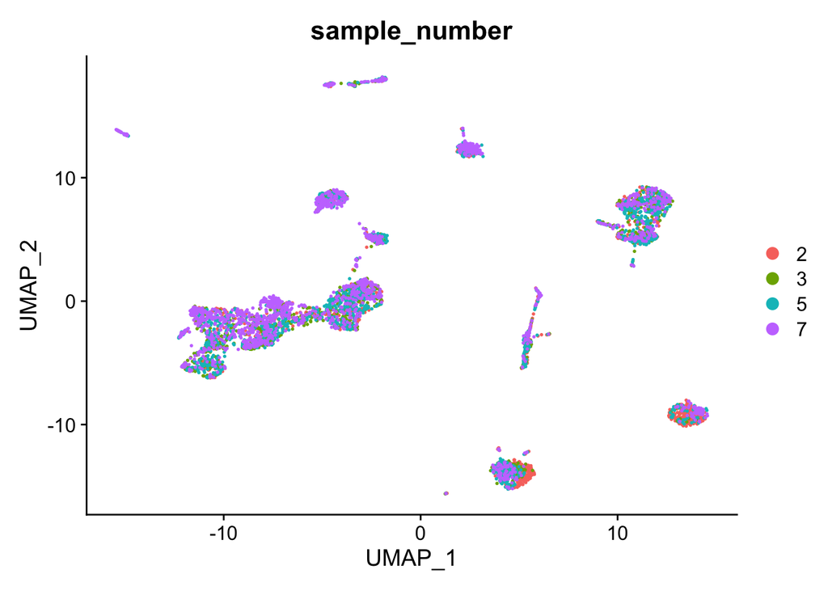

```r
DimPlot(pfc, group.by="sample_number")
```

In some cases it is useful to separate data by batch rather than overlay. To do this we can use the `split.by` option.

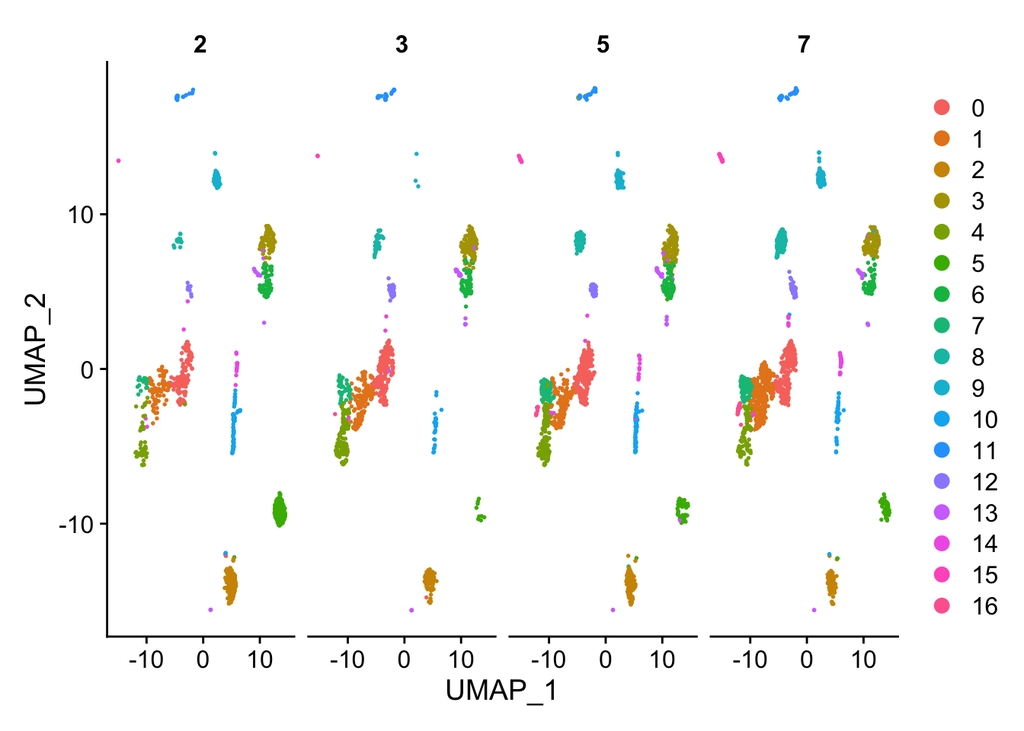

```r
DimPlot(pfc, split.by="sample_number")
```

We can look at the number of cells in each cluster with the `table` function.

In this case we subset our data by the `seurat_clusters` metadata slot, which was added during the clustering step. (You can use the `head(pfc@meta.data)` command to check).

```r
table(pfc@meta.data$seurat_clusters)
```

```
##
##   0   1   2   3   4   5   6   7   8   9  10  11  12  13  14  15  16
## 772 770 491 482 428 364 340 257 243 225 202 148 142  94  76  47  37
```

We can additionally subset by `sample_number` if desired.

```r
table(pfc@meta.data$seurat_clusters, pfc@meta.data$sample_number)
```

```
##
##        2   3   5   7
##   0  122 203 232 215
##   1   80 164 134 392
##   2  185  87 145  74
##   3   86 130 163 103
##   4   54 139 139  96
##   5  260   9  44  51
##   6   61  81 130  68
##   7   24  41  60 132
##   8   17  35  60 131
##   9   50   3  54 118
##   10  68  27  73  34
##   11  16  25  44  63
##   12  11  32  34  65
##   13  14  26  30  24
##   14  18   4  18  36
##   15   2   2  11  32
##   16   0   1  10  26
```

# Identify marker genes

Now that we have clustered our cells, we can work on identifying the cell type(s) present in each cluster. To do this we can use the `FindMarkers()` function in Seurat.

FindMarkers takes a few input arguments:

**Required Arguments**

`object` = the Seurat object you wish to analyze

`ident.1` = the name of the cluster(s) of interest

**Optional Arguments**

`ident.2` = the cluster(s) against which `ident.1` is compared. If this is left blank, Seurat will compare `ident.1` to all other clusters by default.

`only.pos` = will only report positively enriched genes

`min.pct` = only test genes that are detected in a minimum fraction of min.pct cells in either of the two populations. Meant to speed up the function by not testing genes that are very infrequently expressed. Default is 0.1

To see additional arguments, use the `?FindMarkers` command.

### A note on visualization

When a Seurat object is first generated, the count matrix used for its generation is stored in an “assay” called `RNA` within the Seurat object.

When SCTransform is run on a dataset, it creates a new “assay” in the Seurat object called `SCT` in which to store the transformed values. In this process the `RNA` assay is preserved in the background as before.

While SCTransformed values are optimal for clustering cells, the authors of Seurat recommend that marker gene identification and visualization be performed with the count values stored in the `RNA` assay.

To prepare the `RNA` assay, we need to reset it as our default assay and perform a simple log-normalization to scale the values across all cells. (Since SCTransform stored normalized values in the `SCT` assay, the `RNA` assay still contains raw count data, so we need to normalize before performing gene expression analyses.)

```r
# check the current default assay
DefaultAssay(pfc)
```

```
## [1] "SCT"
```

```r
# set the default assay to RNA
DefaultAssay(pfc) <- "RNA"
# normalize the raw RNA counts
pfc <- NormalizeData(pfc)
```

```r
markers <- FindAllMarkers(pfc, only.pos=T)
```